# Practical Machine Learning

Rajeev

4/11/2018

## Practical Machine Learning Course Project

## Background

Using devices such as Jawbone Up, Nike FuelBand, and Fitbit it is now possible to collect a large amount of data about personal activity relatively inexpensively. These type of devices are part of the quantified self movement ??? a group of enthusiasts who take measurements about themselves regularly to improve their health, to find patterns in their behavior, or because they are tech geeks. One thing that people regularly do is quantify how much of a particular activity they do, but they rarely quantify how well they do it. In this project, your goal will be to use data from accelerometers on the belt, forearm, arm, and dumbell of 6 participants. They were asked to perform barbell lifts correctly and incorrectly in 5 different ways. More information is available from the website here: http://groupware.les.inf.puc-rio.br/har (see the section on the Weight Lifting Exercise Dataset).

## Data gethering and cleaning.

### Reading Data

```r
url1<- "https://d396qusza40orc.cloudfront.net/predmachlearn/pml-training.csv"
url2<- "https://d396qusza40orc.cloudfront.net/predmachlearn/pml-testing.csv"

download.file(url1, destfile= "traindat", method= "curl")
download.file(url2, destfile= "testdat", method="curl")
read.csv("traindat",na.strings=c("NA","#DIV/0!",""))-> traindata
read.csv("testdat", na.strings=c("NA","#DIV/0!",""))-> testdata
str(traindata)
```

```
## 'data.frame':    19622 obs. of  160 variables:
##  $ X                       : int  1 2 3 4 5 6 7 8 9 10 ...
##  $ user_name               : Factor w/ 6 levels "adelmo","carlitos",..: 2 2 2 2 2 2 2 2 2 2 ...
##  $ raw_timestamp_part_1    : int  1323084231 1323084231 1323084231 1323084232 1323084232 1323084232 1323084232 1323084232 1323084232 1323084232 ...
##  $ raw_timestamp_part_2    : int  788290 808298 820366 120339 196328 304277 368296 440390 484323 484434 ...
##  $ cvtd_timestamp          : Factor w/ 20 levels "02/12/2011 13:32",..: 9 9 9 9 9 9 9 9 9 9 ...
##  $ new_window              : Factor w/ 2 levels "no","yes": 1 1 1 1 1 1 1 1 1 1 ...
##  $ num_window              : int  11 11 11 12 12 12 12 12 12 12 ...
##  $ roll_belt               : num  1.41 1.41 1.42 1.48 1.48 1.45 1.42 1.42 1.43 1.45 ...
##  $ pitch_belt              : num  8.07 8.07 8.07 8.05 8.07 8.06 8.09 8.13 8.16 8.17 ...
##  $ yaw_belt                : num  -94.4 -94.4 -94.4 -94.4 -94.4 -94.4 -94.4 -94.4 -94.4 -94.4 ...
##  $ total_accel_belt        : int  3 3 3 3 3 3 3 3 3 3 ...
##  $ kurtosis_roll_belt      : num  NA NA NA NA NA NA NA NA NA NA ...
##  $ kurtosis_picth_belt     : num  NA NA NA NA NA NA NA NA NA NA ...
##  $ kurtosis_yaw_belt       : logi  NA NA NA NA NA NA ...
```

[output cut: 86 more lines]

```r
head(traindata,6)
```

```
##   X user_name raw_timestamp_part_1 raw_timestamp_part_2   cvtd_timestamp
## 1 1  carlitos           1323084231               788290 05/12/2011 11:23
## 2 2  carlitos           1323084231               808298 05/12/2011 11:23
## 3 3  carlitos           1323084231               820366 05/12/2011 11:23
## 4 4  carlitos           1323084232               120339 05/12/2011 11:23
## 5 5  carlitos           1323084232               196328 05/12/2011 11:23
## 6 6  carlitos           1323084232               304277 05/12/2011 11:23
##   new_window num_window roll_belt pitch_belt yaw_belt total_accel_belt
## 1         no         11      1.41       8.07    -94.4                3
## 2         no         11      1.41       8.07    -94.4                3
## 3         no         11      1.42       8.07    -94.4                3
## 4         no         12      1.48       8.05    -94.4                3
## 5         no         12      1.48       8.07    -94.4                3
## 6         no         12      1.45       8.06    -94.4                3
##   kurtosis_roll_belt kurtosis_picth_belt kurtosis_yaw_belt
```

[output cut: 265 more lines]

### Cleaing Data

This raw data set had 19622 obsevations and 160 variables but most os the varibales were either “NA” or negative. Hence, eliminating our noise data is required.

```r
#Setting thresh hold for NA or no value and cleaning data
colth<-ncol(traindata)*.95
noNa <- !apply(traindata, 2, function(x) sum(is.na(x)) > colth  || sum(x=="") > colth)
traindata1 <- traindata[, noNa]

#Cleaning near Zero data.
traindata1 <- traindata1[, colSums(is.na(traindata1)) == 0]
testdata1 <- testdata[, colSums(is.na(testdata)) == 0]

#Removing unwanted coloumns

traindata1 <- traindata1[, -(1:7)]
testdata1 <- testdata1[, -(1:7)]
```

After cleaning data number of variable had reduced to 52 and observations count is retained.

## Data Processing and modeling.

Now that the data is cleaned to a great extend this has to be further processed and put under certain model.

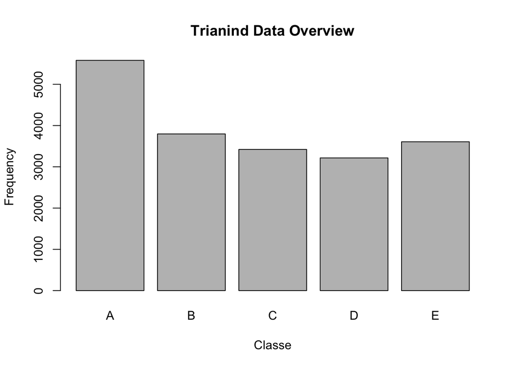

### Further Partitioning the Data.

The training dat set is further partitioned for cross validation.

```r
 partdata<- createDataPartition(y=traindata1$classe, p=.8, list = FALSE)
traindata2<- traindata1[partdata,]
testdata2<- traindata1[-partdata,]
```

Based on the graph above, we can see that each level frequency is within the same order of magnitude of each other. Level A is the most frequent while level D is the least frequent.

### Data Modeling.

Since We have multiple modeling options we will try 2 option to and test the accurac.

#### Modeling 1- Random Forest Model

```r
model1 <- randomForest(classe ~. , data=traindata2, method="class")
predict1 <- predict(model1, testdata2, type = "class")
confusionMatrix(predict1, testdata2$classe)
```

```
## Confusion Matrix and Statistics
##
##           Reference
## Prediction    A    B    C    D    E
##          A 1116    2    0    0    0
##          B    0  757    6    0    0
##          C    0    0  678   10    2
##          D    0    0    0  633    3
##          E    0    0    0    0  716
##
## Overall Statistics
##
##                Accuracy : 0.9941
##                  95% CI : (0.9912, 0.9963)
##     No Information Rate : 0.2845
##     P-Value [Acc > NIR] : < 2.2e-16
##
##                   Kappa : 0.9926
##  Mcnemar's Test P-Value : NA
##
## Statistics by Class:
##
##                      Class: A Class: B Class: C Class: D Class: E
## Sensitivity            1.0000   0.9974   0.9912   0.9844   0.9931
## Specificity            0.9993   0.9981   0.9963   0.9991   1.0000
## Pos Pred Value         0.9982   0.9921   0.9826   0.9953   1.0000
## Neg Pred Value         1.0000   0.9994   0.9981   0.9970   0.9984
## Prevalence             0.2845   0.1935   0.1744   0.1639   0.1838
## Detection Rate         0.2845   0.1930   0.1728   0.1614   0.1825
## Detection Prevalence   0.2850   0.1945   0.1759   0.1621   0.1825
## Balanced Accuracy      0.9996   0.9977   0.9938   0.9918   0.9965
```

#### Modeling 2- LDA Method using train function.

```r
model2<- train(classe~., data = traindata2, method="lda")
predict2 <- predict(model2, testdata2)
confusionMatrix(predict2,testdata2$classe )
```

```
## Confusion Matrix and Statistics
##
##           Reference
## Prediction   A   B   C   D   E
##          A 927 122  73  46  32
##          B  31 503  68  22 135
##          C  86  75 443  91  70
##          D  66  24  79 470  77
##          E   6  35  21  14 407
##
## Overall Statistics
##
##                Accuracy : 0.701
##                  95% CI : (0.6864, 0.7153)
##     No Information Rate : 0.2845
##     P-Value [Acc > NIR] : < 2.2e-16
##
##                   Kappa : 0.621
##  Mcnemar's Test P-Value : < 2.2e-16
##
## Statistics by Class:
##
##                      Class: A Class: B Class: C Class: D Class: E
## Sensitivity            0.8306   0.6627   0.6477   0.7309   0.5645
## Specificity            0.9027   0.9191   0.9006   0.9250   0.9763
## Pos Pred Value         0.7725   0.6627   0.5791   0.6564   0.8427
## Neg Pred Value         0.9306   0.9191   0.9237   0.9461   0.9087
## Prevalence             0.2845   0.1935   0.1744   0.1639   0.1838
## Detection Rate         0.2363   0.1282   0.1129   0.1198   0.1037
## Detection Prevalence   0.3059   0.1935   0.1950   0.1825   0.1231
## Balanced Accuracy      0.8667   0.7909   0.7741   0.8280   0.7704
```

Considered the result of model 1 & 2, it is quote evident that “Model1” produce the more accurcy in prediction compared to “Model 2”. Hence runing the prediction model in the test data set.

### Final Result

Appling model1 on the testing data. Hence final result arrived using model#1 which is RandomForest.

```r
predict3 <- predict(model1, testdata1, type = "class")
predict3
```

```
##  1  2  3  4  5  6  7  8  9 10 11 12 13 14 15 16 17 18 19 20
##  B  A  B  A  A  E  D  B  A  A  B  C  B  A  E  E  A  B  B  B
## Levels: A B C D E
```